# Improper Integrals

A function $f(x)$ is Riemann integrable over an interval $[a,b]$ if some limit involving Riemann sums exists. This limit will fail to exist if $f(x) = \infty$ in $[a,b]$. As well, the Riemann sum idea is undefined if either $a$ or $b$ (or both) are infinite, so the limit won't exist in this case.

To define integrals with either functions having singularities or infinite domains, the idea of an improper integral is introduced with definitions to handle the two cases above.

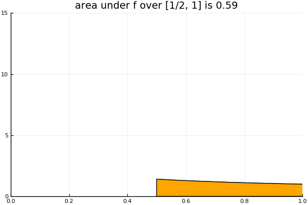

Area under $1/\sqrt{x}$ over $[a,b]$ increases as $a$ gets closer to $0$. Will it grow unbounded or have a limit?

## Infinite domains

Let $f(x)$ be a reasonable function, so reasonable that for any $a < b$ the function is Riemann integrable, meaning $\int_a^b f(x)dx$ exists.

What needs to be the case so that we can discuss the limit over the entire real number line?

Clearly something. The function $f(x) = 1$ is reasonable by the idea above. Clearly the integral over and $[a,b]$ is just $b-a$, but the limit over an unbounded domain would be $\infty$. Even though limits of infinity can be of interest in some cases, not so here. What will ensure that the area is finite over an infinite region?

Or is that even the right question. Now consider $f(x) = \sin(\pi x)$. Over every interval of the type $[-2n, 2n]$ the area is $0$, and over any interval, $[a,b]$ the area never gets bigger than $2$. But still this function does not have a well defined area on an infinite domain.

The right question involves a limit. Fix a finite $a$. We define the definite integral over $[a,\infty)$ to be

\[ ~ \int_a^\infty f(x) dx = \lim_{M \rightarrow \infty} \int_a^M f(x) dx, ~ \]

when the limit exists. Similarly, we define the definite integral over $(-\infty, a]$ through

\[ ~ \int_{-\infty}^a f(x) dx = \lim_{M \rightarrow -\infty} \int_M^a f(x) dx. ~ \]

For the interval $(-\infty, \infty)$ we have need *both* these limits to exist, and then:

\[ ~ \int_{-\infty}^\infty f(x) dx = \lim_{M \rightarrow -\infty} \int_M^a f(x) dx + \lim_{M \rightarrow \infty} \int_a^M f(x) dx. ~ \]

When the integral exists, it is said to *converge*. If it doesn't exist, it is said to *diverge*.

##### Examples

- The function $f(x) = 1/x^2$ is integrable over $[1, \infty)$, as this limit exists:

\[ ~ \lim_{M \rightarrow \infty} \int_1^M \frac{1}{x^2}dx = \lim_{M \rightarrow \infty} -\frac{1}{x}\big|_1^M = \lim_{M \rightarrow \infty} 1 - \frac{1}{M} = 1. ~ \]

- The function $f(x) = 1/x^{1/2}$ is not integrable over $[1, \infty)$, as this limit fails to exist:

\[ ~ \lim_{M \rightarrow \infty} \int_1^M \frac{1}{x^{1/2}}dx = \lim_{M \rightarrow \infty} \frac{x^{1/2}}{1/2}\big|_1^M = \lim_{M \rightarrow \infty} 2\sqrt{M} - 2 = \infty. ~ \]

The limit is infinite, so does not exist except in an extended sense.

- The function $x^n e^{-x}$ for $n = 1, 2, \dots$ is integrable over $[0,\infty)$.

Before showing this, we recall the fundamental theorem of calculus. The limit existing is the same as saying the limit of $F(M) - F(a)$ exists for an antiderivative of $f(x)$.

For this particular problem, it can be shown by integration by parts that for positive, integer values of $n$ that an antiderivative exists of the form $F(x) = p(x)e^{-x}$, where $p(x)$ is a polynomial of degree $n$. But we've seen that for any $n>0$, $\lim_{x \rightarrow \infty} x^n e^{-x} = 0$, so the same is true for any polynomial. So, $\lim_{M \rightarrow \infty} F(M) - F(1) = -F(1)$.

- The function $e^x$ is integrable over $(-\infty, a]$ but not

\[ [a, \infty) \]

for any finite $a$. This is because, $F(M) = e^x$ and this has a limit as $x$ goes to $-\infty$, but not $\infty$.

- The sinc function $f(x) = \sin(\pi x)/(\pi x)$ does not have a nice antiderivative. Seeing if the limit exists is a bit of a problem. However, this function is important enough that there is a built-in function, `Si`, that computes $\int_0^x \sin(u)/u\cdot du$. This function can be used through `sympy.Si(...)`:

```julia
using CalculusWithJulia    # loads `SymPy`, `QuadGK`
@vars M
limit(sympy.Si(M), M => oo)
```

\begin{equation*}\frac{\pi}{2}\end{equation*}

### Numeric integrals

The `quadgk` function (available through `QuadGK` which is loaded with `CalculusWithJulia`) is able to accept `Inf` and `-Inf` as endpoints of the interval. For example, this will integrate $e^{-x^2/2}$ over the real line:

```julia
f(x) = exp(-x^2/2)
quadgk(f, -Inf, Inf)
```

```
(2.506628274639168, 3.6084380708526996e-8)
```

(If may not be obvious, but this is $\sqrt{2\pi}$.)

## Singularities

Suppose $\lim_{x \rightarrow c}f(x) = \infty$ or $-\infty$. Then a Riemann sum that contains an interval including $c$ will not be finite if the point chosen in the interval is $c$. Though we could choose another point, this is not enough as the definition must hold for any choice of the $c_i$.

However, if $c$ is isolated, we can get close to $c$ and see how the area changes.

Suppose $a < c$, we define $\int_a^c f(x) dx = \lim_{M \rightarrow c-} \int_a^c f(x) dx$. If this limit exists, the definite integral with $c$ is well defined. Similarly, the integral from $c$ to $b$, where $b > c$, can be defined by a right limit going to $c$. The integral from $a$ to $b$ will exist if both the limits are finite.

##### Examples

- Consider the example of the initial illustration, $f(x) = 1/\sqrt{x}$ at $0$. Here $f(0)= \infty$, so the usual notion of a limit won't apply to $\int_0^1 f(x) dx$. However,

\[ ~ \lim_{M \rightarrow 0+} \int_M^1 \frac{1}{\sqrt{x}} dx = \lim_{M \rightarrow 0+} \frac{\sqrt{x}}{1/2} \big|_M^1 = \lim_{M \rightarrow 0+} 2(1) - 2\sqrt{M} = 2. ~ \]

The cases $f(x) = x^{-n}$ for $n > 0$ are tricky. For $n > 1$, the functions can be integrated over $[1,\infty)$, but not $(0,1]$. For $0 < n < 1$, the functions can be integrated over $(0,1]$ but not $[1, \infty)$.

- Now consider $f(x) = 1/x$. Is this integral $\int_0^1 1/x \cdot dx$ defined? It will be *if* this limit exists:

\[ ~ \lim_{M \rightarrow 0+} \int_M^1 \frac{1}{x} dx = \lim_{M \rightarrow 0+} \log(x) \big|_M^1 = \lim_{M \rightarrow 0+} \log(1) - \log(M) = \infty. ~ \]

As the limit does not exist, the function is not integrable around $0$.

- `SymPy` may give answers which do not coincide with our definitions, as it uses complex numbers as a default assumption. In this case it returns `NaN` for an integral with no answer:

```julia
@vars x
integrate(1/x, (x, -1, 1))
```

\begin{equation*}\mathrm{NaN}\end{equation*}

- Suppose you know $\int_1^\infty x^2 f(x) dx$ exists. Does this imply $\int_0^1 f(1/x) dx$ exists?

We need to consider the limit of $\int_M^1 f(1/x) dx$. We try the $u$-substitution $u(x) = 1/x$. This gives $du = -(1/x^2)dx = -u^2 dx$. So, the substitution becomes:

\[ ~ \int_M^1 f(1/x) dx = \int_{1/M}^{1/1} f(u) (-u^2) du = \int_1^{1/M} u^2 f(u) du. ~ \]

But the limit as $M \rightarrow 0$ of $1/M$ is the same going to $\infty$, so the right side will converge by the assumption. Thus we get $f(1/x)$ is integrable over $(0,1]$.

### Numeric integration

So far our use of the `quadgk` function specified the region to integrate via `a`, `b`, as in `quadgk(f, a, b)`. In fact, it can specify values in between for which the function should not be sampled. For example, were we to integrate $1/\sqrt{\lvert x\rvert}$ over $[-1,1]$, we would want to avoid $0$ as a point to sample. Here is how:

```julia
f(x) = 1 / sqrt(abs(x))
quadgk(f, -1, 0, 1)
```

```
(3.999999962817228, 5.736423067171012e-8)
```

Just trying `quadgk(f, -1, 1)` leads to a `DomainError`, as `0` will be one of the points sampled. The general call is like `quadgk(f, a, b, c, d,...)` which integrates over $(a,b)$ and $(b,c)$ and $(c,d)$, $\dots$. The algorithm is not supposed to evaluate the function at the endpoints of the intervals.

## Probability applications

A probability density is a function $f(x) \geq 0$ which is integrable on $(-\infty, \infty)$ and for which $\int_{-\infty}^\infty f(x) dx =1$. The cumulative distribution function is defined by $F(x)=\int_{-\infty}^x f(u) du$.

Probability densities are good example of using improper integrals.

- Show that $f(x) = (1/\pi) 1/(1 + x^2)$ is a probability density function.

We need to show that the integral exists and is $1$. For this, we use the fact that $(1/\pi) \cdot \tan^{-1}(x)$ is an antiderivative. Then we have:

\[ \lim_{M \rightarrow \infty} F(M) = (1/\pi) \cdot \pi/2 \]

and as $\tan^{-1}(x)$ is odd, we must have $F(-\infty) = \lim_{M \rightarrow -\infty} f(M) = -(1/\pi) \cdot \pi/2$. All told, $F(\infty) - F(-\infty) = 1/2 - (-1/2) = 1$.

- Show that $f(x) = 1/(b-a)$ for $a \leq x \leq b$ and $0$ otherwise is a probability density.

The integral for $-\infty$ to $a$ of $f(x)$ is just an integral of the constant $0$, so will be $0$. (This is the only constant with finite area over an infinite domain.) Similarly, the integral from $b$ to $\infty$ will be $0$. This means:

\[ ~ \int_{-\infty}^\infty f(x) dx = \int_a^b \frac{1}{b-a} dx = 1. ~ \]

- Show that if $f(x)$ is a probability density then so is $f(x-c)$ for any $c$.

We have by the $u$-substitution

\[ ~ \int_{-\infty}^\infty f(x-c)dx = \int_{u(-\infty)}^{u(\infty)} f(u) du = \int_{-\infty}^\infty f(u) du = 1. ~ \]

The key is that we can use the regular $u$-substitution formula provided $\lim_{M \rightarrow \infty} u(M) = u(\infty)$ is defined. (The *informal* notation $u(\infty)$ is defined by that limit.)

- If $f(x)$ is a probability density, then so is $(1/h) f((x-c)/h)$ for any $c, h > 0$.

Again, by a $u$ substitution with, now, $u(x) = (x-c)/h$, we have $du = (1/h) \cdot dx$ and the result follows just as before:

\[ ~ \int_{-\infty}^\infty \frac{1}{h}f(\frac{x-c}{h})dx = \int_{u(-\infty)}^{u(\infty)} f(u) du = \int_{-\infty}^\infty f(u) du = 1. ~ \]

- If $F(x) = 1 - e^{-x}$, for $x \geq 0$, and $0$ otherwise, find $f(x)$.

We want to just say $F'(x)= e^{-x}$ so $f(x) = e^{-x}$. But some care is needed. First, that isn't right. The derivative for $x<0$ of $F(x)$ is $0$, so $f(x) = 0$ if $x < 0$. What about for $x>0$? The derivative is $e^{-x}$, but is that the right answer? $F(x) = \int_{-\infty}^x f(u) du$, so we have to at least discuss if the $-\infty$ affects things. In this case, and in general the answer is *no*. For any $x$ we can find $M < x$ so that we have $F(x) = \int_{-\infty}^M f(u) du + \int_M^x f(u) du$. The first part is a constant, so will have derivative $0$, the second will have derivative $f(x)$, if the derivative exists (and it will exist at $x$ if the derivative is continuous in a neighborhood of $x$).

Finally, at $x=0$ we have an issue, as $F'(0)$ does not exist. The left limit of the secant line approximation is $0$, the right limit of the secant line approximation is $1$. So, we can take $f(x) = e^{-x}$ for $x > 0$ and $0$ otherwise, noting that redefining $f(x)$ at a point will not effect the integral as long as the point is finite.

## Questions

###### Question

Is $f(x) = 1/x^{100}$ integrable around $0$?

Yes

No

###### Question

Is $f(x) = 1/x^{1/3}$ integrable around $0$?

Yes

No

###### Question

Is $f(x) = x\cdot\log(x)$ integrable on $[1,\infty)$?

Yes

No

###### Question

Is $f(x) = \log(x)/ x$ integrable on $[1,\infty)$?

Yes

No

###### Question

Is $f(x) = \log(x)$ integrable on $[1,\infty)$?

Yes

No

###### Question

Compute the integral $\int_0^\infty 1/(1+x^2) dx$.

###### Question

Compute the the integral $\int_1^\infty \log(x)/x^2 dx$.

###### Question

Compute the integral $\int_0^2 (x-1)^{2/3} dx$.

###### Question

From the relationship that if $0 \leq f(x) \leq g(x)$ then $\int_a^b f(x) dx \leq \int_a^b g(x) dx$ it can be deduced that

- if $\int_a^\infty f(x) dx$ diverges, then so does $\int_a^\infty g(x) dx$.
- if $\int_a^\infty g(x) dx$ converges, then so does $\int_a^\infty f(x) dx$.

Let $f(x) = \lvert \sin(x)/x^2 \rvert$.

What can you say about $\int_1^\infty f(x) dx$, as $f(x) \leq 1/x^2$ on $[1, \infty)$?

It is convergent

It is divergent

Can't say

Let $f(x) = \lvert \sin(x) \rvert / x$.

What can you say about $\int_1^\infty f(x) dx$, as $f(x) \leq 1/x$ on $[1, \infty)$?

It is convergent

It is divergent

Can't say

Let $f(x) = 1/\sqrt{x^2 - 1}$. What can you say about $\int_1^\infty f(x) dx$, as $f(x) \geq 1/x$ on $[1, \infty)$?

It is convergent

It is divergent

Can't say

Let $f(x) = 1 + 4x^2$. What can you say about $\int_1^\infty f(x) dx$, as $f(x) \leq 1/x^2$ on $[1, \infty)$?

It is convergent

It is divergent

Can't say

Let $f(x) = \lvert \sin(x)^{10}\rvert/e^x$. What can you say about $\int_1^\infty f(x) dx$, as $f(x) \leq e^{-x}$ on $[1, \infty)$?

It is convergent

It is divergent

Can't say

###### Question

The difference between "blowing up" at $0$ versus being integrable at $\infty$ can be seen to be related through the $u$-substitution $u=1/x$. With this $u$-substitution, what becomes of $\int_0^1 x^{-2/3} dx$?

$\int_0^\infty 1/u \cdot du$

$\int_0^1 u^{2/3} \cdot du$

$\int_1^\infty u^{2/3}/u^2 \cdot du$

###### Question

The antiderivative of $f(x) = 1/\pi \cdot 1/\sqrt{x(1-x)}$ is $F(x)=(2/\pi)\cdot \sin^{-1}(\sqrt{x})$.

Find $\int_0^1 f(x) dx$.